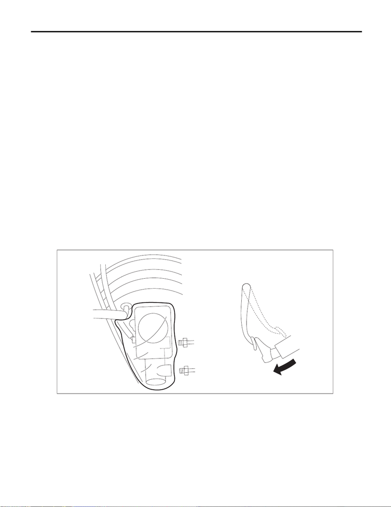

Air Bleeding

11.Air Bleeding

A: PROCEDURE

CAUTION:

• Do not allow brake fluid to come in contact with the painted surface of the vehicle body. If it does,

wash off with water and wipe away completely.

• Prepare a container to catch grease or oil, etc. If any grease or oil spills, wipe it off and clean im-

mediately to prevent from penetrating into floor or flowing outside.

• Avoid mixing brake fluid of different brands to prevent fluid performance from degrading.

• Be careful not to allow dirt or dust to enter the reservoir tank.

1. MASTER CYLINDER

NOTE:

• When the master cylinder assembly is replaced or the reservoir tank is empty, bleed the brake master cyl-

inder and the clutch master cylinder (MT model).

• If bleeding of the master cylinder assembly is not necessary, omit the following procedures, and perform

bleeding of the brake line. <Ref. to BR-67, BRAKE LINE, PROCEDURE, Air Bleeding.>

1) Add the brake fluid to the reservoir tank of the master cylinder assembly.

NOTE:

• MT model: Add the brake fluid until it flows out from the clutch hose nipple.

• Except for MT model: Add the brake fluid up to the MAX level.

• While bleeding air, keep the reservoir tank filled with brake fluid at MIN level or higher to prevent entry of

air.

2) Disconnect the brake line at primary and secondary sides.

3) Wrap the master cylinder assembly with a plastic bag.

4) Depress the brake pedal slowly and hold it.

BR-00943

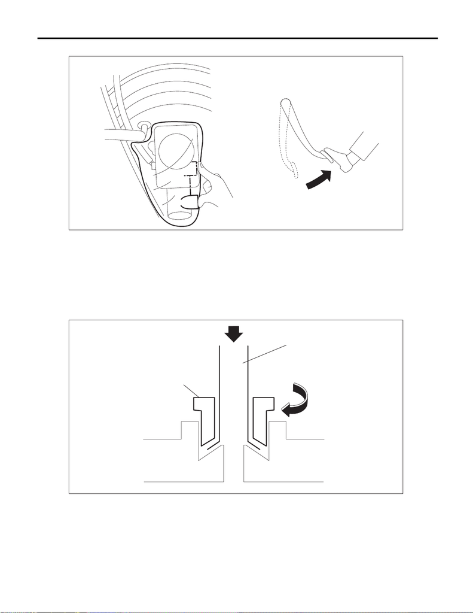

5) Plug the outlet plug with your finger, and then release the brake pedal.

6) Repeat the step 4) and 5) several times.

7) Remove the plastic bag.

8) Turn and tighten the flare nut (b) by hand while pressing the brake pipe (a) toward the master cylinder as-

sembly side.

CAUTION:

Be careful not to make scratches or other damage to the inside surface of the brake pipe flare.

Tightening torque:

Brake pipe flare nut: 19 N·m (1.9 kgf-m, 14.0 ft-lb)

9) Bleed air from the brake line. <Ref. to BR-67, BRAKE LINE, PROCEDURE, Air Bleeding.>

BR-00944

BR-01088

(a)

(b)

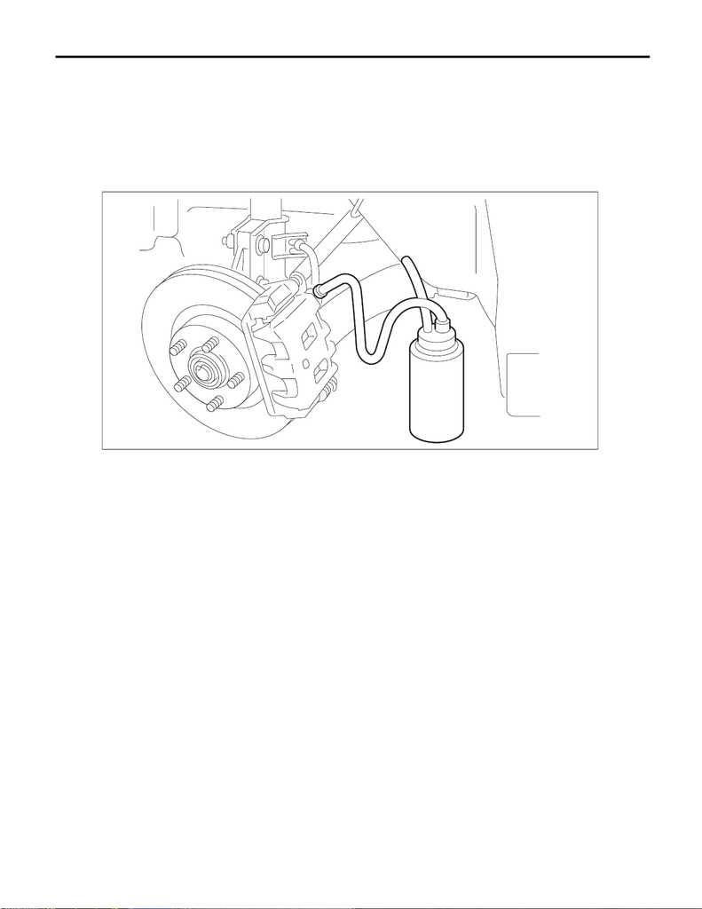

2. BRAKE LINE

1) When the master cylinder assembly is replaced or the reservoir tank is empty, bleed the master cylinder

assembly before bleeding the brake line. <Ref. to BR-65, MASTER CYLINDER, PROCEDURE, Air Bleed-

ing.>

2) Fill the reservoir tank of the master cylinder assembly with brake fluid.

NOTE:

While bleeding air, keep the reservoir tank filled with brake fluid to prevent entry of air.

3) Attach one end of the vinyl tube to the bleeder - screw and the other end to the brake fluid container.

4) Depress the brake pedal several times, and hold it.

5) Loosen the bleeder - screw to drain brake fluid. Tighten the bleeder - screw quickly, and release the brake

pedal.

6) Repeat the steps 4) to 5) until there are no more air bubbles in the vinyl tube.

7) Repeat the steps from 2) to 6) above to bleed air from each wheel.

NOTE:

Perform air bleed starting in the order from the farthest wheel cylinder from the master cylinder assembly.

8) Securely tighten the bleeder - screw.

Tightening torque:

Bleeder - screw: 8 N·m (0.8 kgf-m, 5.9 ft-lb)

9) Check that there are no brake fluid leaks in the entire brake system.

BR-00942

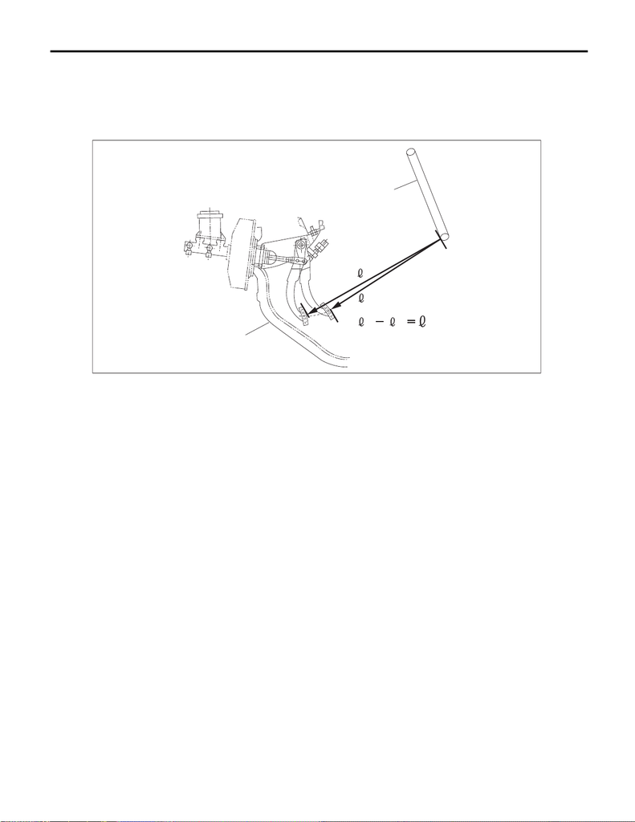

10) Check the pedal stroke.

(1) Warm up the engine until the engine speed stabilizes.

(2) Depress and hold the brake pedal with a force of 500 N (51 kgf, 112 lbf).

(3) Adjust the tilt position of the steering wheel to the lowest position.

(4) Measure the distance between brake pedal and steering wheel.

(5) Release the pedal, and measure the distance between pedal and steering wheel again.

Specification of pedal stroke:

110 mm (4.33 in) or less when depressing the pedal with a force of 500 N (51 kgf, 112 lbf)

11) If the distance is more than specification, there is a possibility of air being caught in the brake line. Bleed

the brake line of all air until the pedal stroke meets the specification.

12) Operate the hydraulic control unit in the sequence control mode. <Ref. to VDC-17, ABS Sequence Con-

trol.>

13) Check the pedal stroke again.

14) If the distance is more than specification, there is a possibility of air being caught in the hydraulic unit. Re-

peat above steps 2) to 9) until the pedal stroke meets the specification.

15) Fill the reservoir tank with brake fluid up to the “MAX” level.

16) Perform a road test and ensure that the brakes operate normally.

(a) Steering wheel (b) Toe board

(a)

(b)

1

BR-00945

1

2

2